# PhaseOne_Liebel

### Final Figure: Smoothed Touch Distribution Across Time

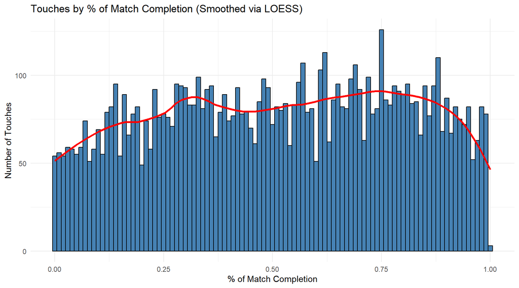

This normalized histogram shows how touches distribute across matches regardless of game length.

This pattern may reflect the evolution of interpersonal dynamics and game tempo. Future analyses may compare this with goal distribution, player fatigue markers, or team-specific variations.

## Touches before first goal.

Hypothesis: Teams that score the first goal of a match exhibit a higher touch count (up to that point) than their average in matches where they did not score first.

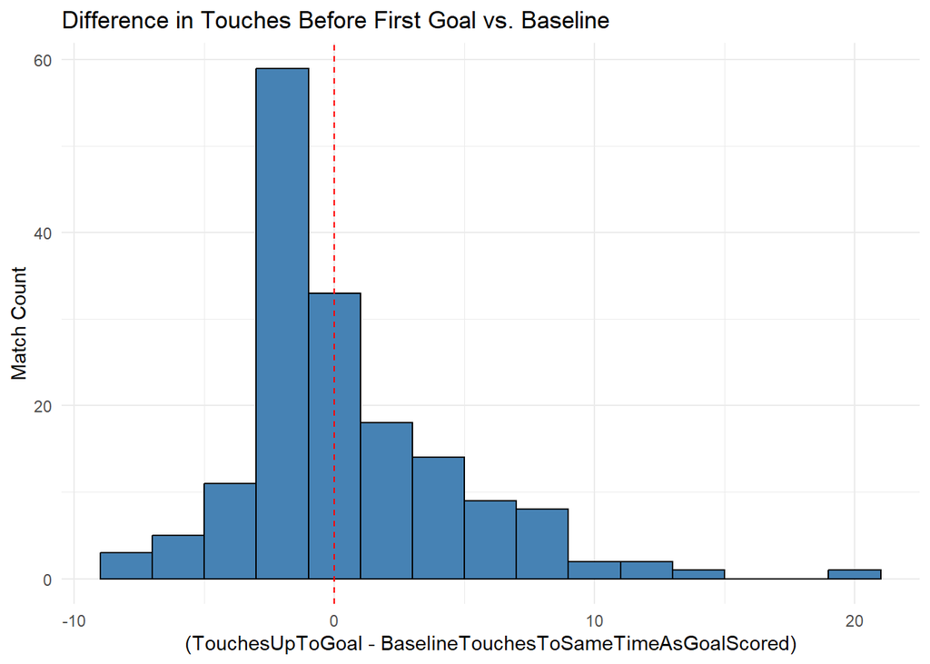

```
##
##  Wilcoxon signed rank test with continuity correction
##
## data:  baseline_touch_counts$Diff
## V = 6605.5, p-value = 0.4977
## alternative hypothesis: true location is greater than 0
```

Result: No significant difference; elevated pre-goal touch is not universally predictive.

## Touch by match outcome.

Compared number of touches before the average first-goal time (~30% match completion) for teams that won vs. lost.

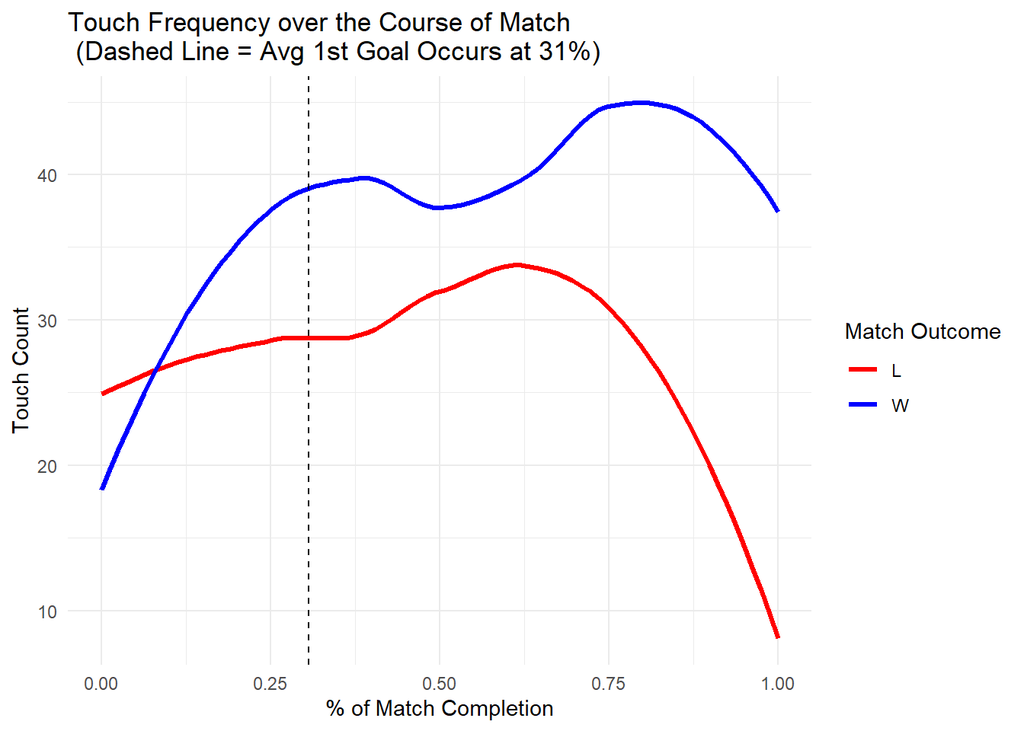

## Early Touch vs Outcome

Is there a statistically significant difference in early touches between winning and losing teams, if we define ‘early’ as up to X% of match time?

Basically asking when in the game does touch start to matter?

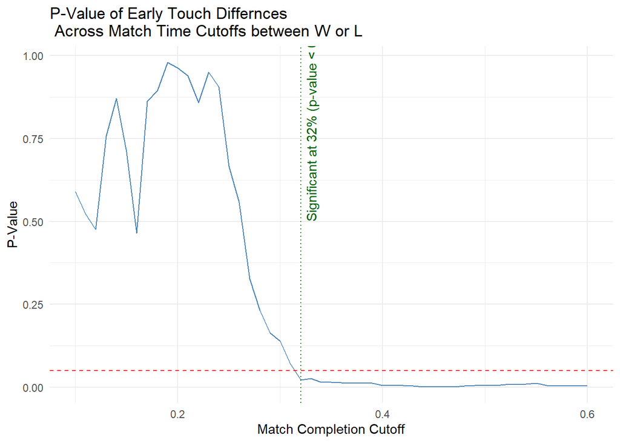

```
##
##  Wilcoxon rank sum test with continuity correction
##
## data:  EarlyTouches by Outcome
## W = 9497, p-value = 0.08755
## alternative hypothesis: true location shift is not equal to 0
```

Significant at 32%, which is within a few percentage points of the average first goal at 30%.

*This aligns with a reverse association: once a team begins to gain the upper hand (possession, control, confidence), they touch more — even before the goal, but closer to it in time.*

## Post-goal Behavior

If a team scores the first goal, does their subsequent touch behavior differ depending on whether they go on to win or lose the match?

Have winning teams started to touch more than losing teams at this point?

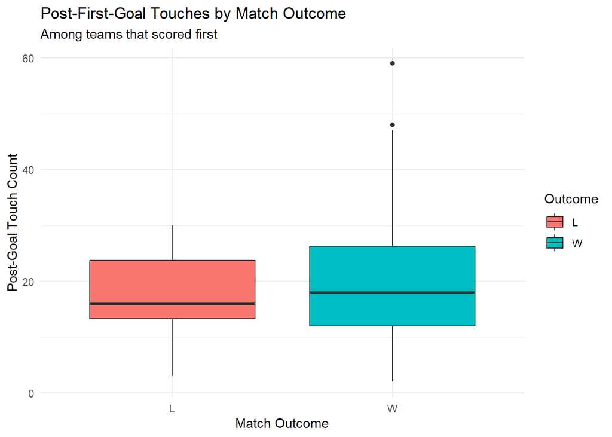

```
##
##  Wilcoxon rank sum test with continuity correction
##
## data:  PostGoalTouches by Outcome
## W = 1040.5, p-value = 0.5085
## alternative hypothesis: true location shift is not equal to 0
```

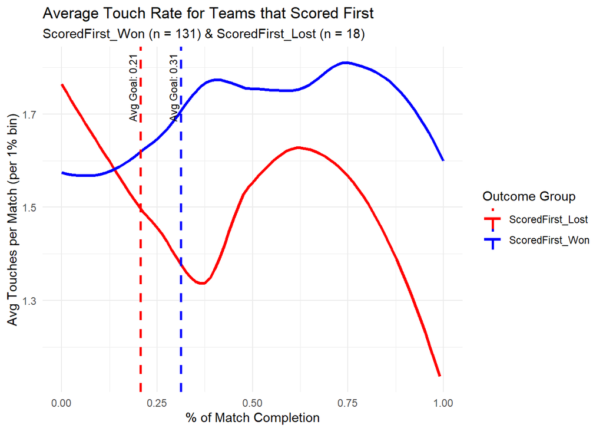

Result: No statistically significant difference, but visual analysis shows touch rate maintenance or increase is more common in wins.

# *8. Inter-rater Reliability*

This section evaluates inter-rater reliability (IRR) across 12 shared matches using multiple perspectives: - Total counts of touches - Counts of reciprocal and non-reciprocal touches - Intraclass correlation coefficients (ICC)

```r
library(tidyverse)
library(data.table)
library(broom)
library(janitor)
library(readxl)
library(rmarkdown)
library(readr)
library(dplyr)
library(irr)
library(fuzzyjoin)
library(knitr)

# Situations excluded from core analysis for these hypotheses: Goals For/Against, Substitutions
Exclude_Touch <- c("TA", "CO", "NEG")
Exclude_Situation <- c("GF", "GA", "SUB")

Interrater <- Touches_interrater %>%  #duplicate and filter
  filter(!(HapticRitual %in% Exclude_Touch)) %>%
  filter(!(Situation %in% Exclude_Situation))

############################ Simple Frequency Check ############################

#Count check per match (simply how many each rater saw)

touch_counts <- Interrater %>%
  group_by(SeasonMatchNumber, Rater) %>%
  summarise(TouchCount = n(), .groups = "drop")

# Plot frequency per match per rater
freq_per_match_perrater_plot <- ggplot(touch_counts, aes(x = factor(SeasonMatchNumber), y = TouchCount, fill = Rater)) +
  geom_bar(stat = "identity", position = "dodge") +
  labs(title = "Touch Count per Match by Rater",
       x = "Season Match Number",
       y = "Touch Count") +
  theme_minimal() +
  theme(axis.text.x = element_text(angle = 45, hjust = 1))

###ICC - Intraclass Correlation Coefficient - Interval data:

# reshape your data: rows = matches, columns = raters
icc_data <- Interrater %>%
  group_by(SeasonMatchNumber, Rater) %>%
  summarise(Count = n(), .groups = "drop") %>%
  pivot_wider(names_from = Rater, values_from = Count)

# Apply ICC (two-way random effects model)
icc_result <- icc(icc_data[,-1], model = "twoway", type = "agreement", unit = "single")


############################ Simple Reciprocity Check ############################


Reciprocal_IR <- Touches_interrater %>%
  filter(!(HapticRitual %in% Exclude_Touch)) %>%
  filter(!(Situation %in% Exclude_Situation)) %>%
  mutate(
    Reciprocity = str_trim(Reciprocal),
    ReciprocityType = case_when(
      Reciprocity %in% c("Y", "G") ~ "Reciprocal",
      Reciprocity == "N" ~ "NonReciprocal",
      TRUE ~ NA_character_
    )
  ) %>%
  filter(!is.na(ReciprocityType))

#Count how many touches each rater coded as reciprocal vs non-reciprocal
Recip_Counts <- Reciprocal_IR %>%
  group_by(SeasonMatchNumber, Rater, ReciprocityType) %>%
  summarise(Count = n(), .groups = "drop") %>%
  pivot_wider(names_from = ReciprocityType, values_from = Count, values_fill = 0)


#Group by match and rater
Recip_Counts <- Reciprocal_IR %>%
  group_by(SeasonMatchNumber, Rater, ReciprocityType) %>%
  summarise(Count = n(), .groups = "drop") %>%
  pivot_wider(names_from = ReciprocityType, values_from = Count, values_fill = 0)

icc_data_recip <- Recip_Counts %>%
  select(SeasonMatchNumber, Rater, Reciprocal) %>%
  pivot_wider(names_from = Rater, values_from = Reciprocal)

icc_result_recip <- icc(icc_data_recip[,-1], model = "twoway", type = "agreement", unit = "single")


icc_data_nonrecip <- Recip_Counts %>%
  select(SeasonMatchNumber, Rater, NonReciprocal) %>%
  pivot_wider(names_from = Rater, values_from = NonReciprocal)

icc_result_nonrecip <- icc(icc_data_nonrecip[,-1], model = "twoway", type = "agreement", unit = "single")

#Make some charts

# Filter for reciprocal touches
recip_counts_plot <- Reciprocal_IR %>%
  filter(ReciprocityType == "Reciprocal") %>%
  group_by(SeasonMatchNumber, Rater) %>%
  summarise(Count = n(), .groups = "drop")

# Plot
reciprocal_touch_count_per_rater <- ggplot(recip_counts_plot, aes(x = factor(SeasonMatchNumber), y = Count, fill = Rater)) +
  geom_bar(stat = "identity", position = "dodge") +
  labs(
    title = "Reciprocal Touch Count per Match by Rater",
    x = "Season Match Number",
    y = "Reciprocal Touch Count"
  ) +
  theme_minimal() +
  theme(axis.text.x = element_text(angle = 45, hjust = 1))

# Filter for non-reciprocal touches
nonrecip_counts_plot <- Reciprocal_IR %>%
  filter(ReciprocityType == "NonReciprocal") %>%
  group_by(SeasonMatchNumber, Rater) %>%
  summarise(Count = n(), .groups = "drop")

# Plot
nonreciprocal_touch_count_per_rater <- ggplot(nonrecip_counts_plot, aes(x = factor(SeasonMatchNumber), y = Count, fill = Rater)) +
  geom_bar(stat = "identity", position = "dodge") +
  labs(
    title = "Non-Reciprocal Touch Count per Match by Rater",
    x = "Season Match Number",
    y = "Non-Reciprocal Touch Count"
  ) +
  theme_minimal() +
  theme(axis.text.x = element_text(angle = 45, hjust = 1))


##########Global
# Total: Keep everything except TA, CO, NEG (but DO allow "IT")
Interrater_Total <- Touches_interrater %>%
  filter(!(HapticRitual %in% Exclude_Touch)) %>%
  filter(!(Situation %in% Exclude_Situation)) %>%
  group_by(Rater) %>%
  summarise(Count = n(), .groups = "drop") %>%
  mutate(TouchType = "Total")

# Recip / NonRecip: Apply stricter filter (exclude IT)
Interrater_RecipFiltered <- Touches_interrater %>%
  filter(!(HapticRitual %in% Exclude_Touch)) %>%
  filter(!(Situation %in% Exclude_Situation)) %>%
  mutate(
    Reciprocity = str_trim(Reciprocal),
    TouchType = case_when(
      Reciprocity %in% c("Y", "G") ~ "Reciprocal",
      Reciprocity == "N" ~ "NonReciprocal",
      TRUE ~ NA_character_
    )
  ) %>%
  filter(!is.na(TouchType))

Interrater_Specific <- Interrater_RecipFiltered %>%
  group_by(Rater, TouchType) %>%
  summarise(Count = n(), .groups = "drop")

# Combine all
Global_Touch_Summary <- bind_rows(Interrater_Total, Interrater_Specific) %>%
  mutate(TouchType = factor(TouchType, levels = c("Total", "Reciprocal", "NonReciprocal")))

Global_Touch_Summary_plot <- ggplot(Global_Touch_Summary, aes(x = TouchType, y = Count, fill = Rater)) +
  geom_bar(stat = "identity", position = "dodge") +
  labs(
    title = "Global Comparison of Touch Counts by Rater (Filtered Reciprocities Only)",
    x = "Touch Type",
    y = "Total Count",
    fill = "Rater"
  ) +
  theme_minimal()

##ICC Table

# Build total count per match/rater
icc_data_total <- Touches_interrater %>%
  filter(!(HapticRitual %in% Exclude_Touch)) %>%
  filter(!(Situation %in% Exclude_Situation)) %>%  # NOTE: only GF, GA, SUB excluded (not IT)
  group_by(SeasonMatchNumber, Rater) %>%
  summarise(Count = n(), .groups = "drop") %>%
  pivot_wider(names_from = Rater, values_from = Count)

# Already done earlier:
icc_result_total <- icc(icc_data_total[,-1], model = "twoway", type = "agreement", unit = "single")
icc_result_recip <- icc(icc_data_recip[,-1], model = "twoway", type = "agreement", unit = "single")
icc_result_nonrecip <- icc(icc_data_nonrecip[,-1], model = "twoway", type = "agreement", unit = "single")

# Extract results into a data frame
icc_summary <- tibble(
  TouchType = c("Total", "Reciprocal", "NonReciprocal"),
  ICC = c(icc_result_total$value, icc_result_recip$value, icc_result_nonrecip$value),
  Lower_CI = c(icc_result_total$lbound, icc_result_recip$lbound, icc_result_nonrecip$lbound),
  Upper_CI = c(icc_result_total$ubound, icc_result_recip$ubound, icc_result_nonrecip$ubound)
)

library(knitr)
library(kableExtra)

icc_summary %>%
  mutate(across(where(is.numeric), round, 3)) %>%
  kable(caption = "ICC Values by Touch Type", align = "c") %>%
  kable_styling(full_width = FALSE)
```

ICC Values by Touch Type

| TouchType | ICC | Lower_CI | Upper_CI |
| --- | --- | --- | --- |
| Total | 0.788 | 0.551 | 0.926 |
| Reciprocal | 0.817 | 0.579 | 0.939 |
| NonReciprocal | 0.677 | 0.374 | 0.881 |

## Touch counts by rater and match

We first examine the total touch counts coded by each rater per match to check for discrepancies.

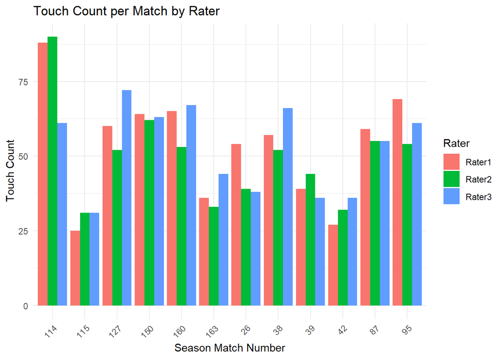

```
##  Single Score Intraclass Correlation
##
##    Model: twoway
##    Type : agreement
##
##    Subjects = 12
##      Raters = 3
##    ICC(A,1) = 0.788
##
##  F-Test, H0: r0 = 0 ; H1: r0 > 0
##  F(11,23.9) = 11.9 , p = 3.33e-07
##
##  95%-Confidence Interval for ICC Population Values:
##   0.551 < ICC < 0.926
```

# Reciprocity check

Reciprocal

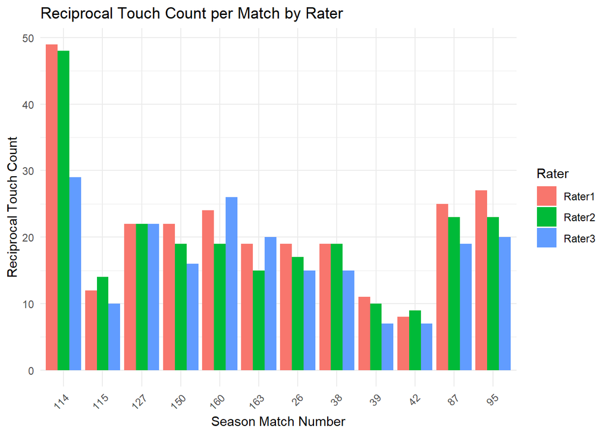

```
##  Single Score Intraclass Correlation
##
##    Model: twoway
##    Type : agreement
##
##    Subjects = 12
##      Raters = 3
##    ICC(A,1) = 0.817
##
##  F-Test, H0: r0 = 0 ; H1: r0 > 0
##  F(11,16.7) = 18.1 , p = 3.59e-07
##
##  95%-Confidence Interval for ICC Population Values:
##   0.579 < ICC < 0.939
```

Non-Reciprocal

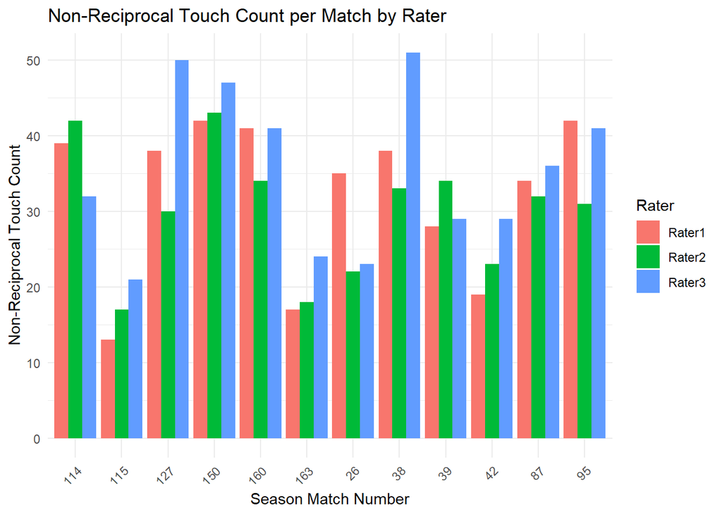

```
##  Single Score Intraclass Correlation
##
##    Model: twoway
##    Type : agreement
##
##    Subjects = 12
##      Raters = 3
##    ICC(A,1) = 0.677
##
##  F-Test, H0: r0 = 0 ; H1: r0 > 0
##  F(11,20.5) = 8.43 , p = 2.12e-05
##
##  95%-Confidence Interval for ICC Population Values:
##   0.374 < ICC < 0.881
```

Global IRR

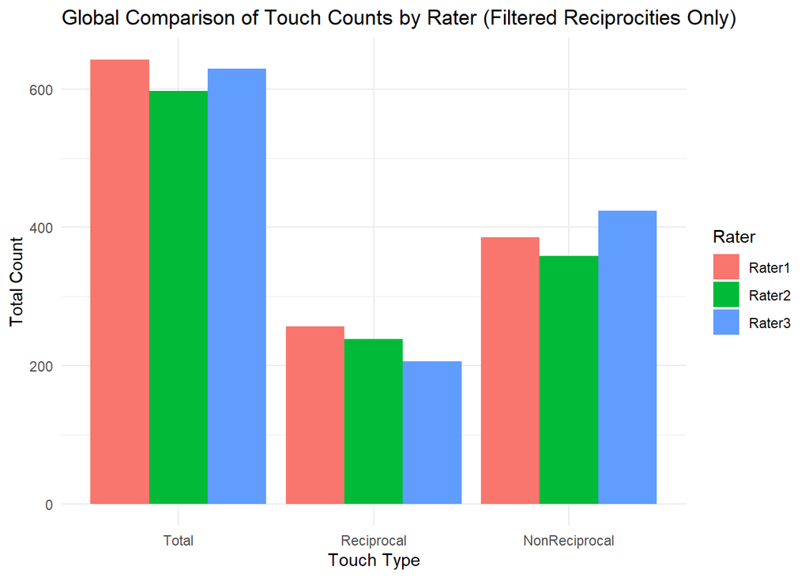

```
## # A tibble: 3 × 4
##   TouchType       ICC Lower_CI Upper_CI
##   <chr>         <dbl>    <dbl>    <dbl>
## 1 Total         0.788    0.551    0.926
## 2 Reciprocal    0.817    0.579    0.939
## 3 NonReciprocal 0.677    0.374    0.881
```